# 1. Nearest Neighbours and the Curse of Dimensionality

## 1.a.

### 1.a.i. expected value

We have $$ Z=|X-Y|^2 = (X-Y)^2 = X^2-2XY+Y^2 $$ and $$ E[Z] = E[X^2]-E[2XY]+E[Y^2] $$

For a function $f(x)$ where $x ~ \sim \text{Uniform}(a,b)$, its expected value is $$E[f(x)]=\int_a^b f(x) \cdot \frac{1}{b-a}dx$$

We have both X and Y are in uniform distribution from 0 and 1. $$X,Y \sim \text{Uniform}(0,1)$$ so $$E[f(x)]=\int_0^1 f(x)dx$$

- for $X^2$ and $Y^2$: $$E[X^2] = E[Y^2] = \int_0^1 x^2dx = \frac{1^3}{3} - \frac{0^3}{3} = \frac{1}{3}$$
- for $X$ and $Y$ themselves: $$E[X] = E[Y] = \frac{1}{2}$$
- so for $2XY$: $$E[2XY] = 2\cdot \frac{1}{2}\cdot\frac{1}{2} =\frac{1}{2}$$ Therefore, $$E[Z] = \frac{1}{3}-\frac{1}{2}+\frac{1}{3} = \frac{1}{6}$$ .

### 1.a.ii. variance

The variance of Z $$Var(Z)=E[(Z-\mu_Z)^2]$$ where $\mu_Z$ is the mean of Z, which is actually just $E[Z]$. $$Var(Z)=E[(Z-E[Z])^2]$$ $$=E[(Z^2-2ZE[Z]+E[Z]^2)]$$ $$=E[Z^2]-2E[Z]E[Z]+E[Z]^2$$ $$=E[Z^2]-2E[Z]^2+E[Z]^2$$ $$=E[Z^2]-E[Z]^2$$ So now we only need to calculate $E[Z^2]$. $$E[Z^2]=E[(X-Y)^4]$$ $$=E[X^4-4X^3Y+6X^2Y^2-4XY^3+Y^4]$$ $$=E[X^4]-4E[X^3]E[Y]+6E[X^2]E[Y^2]-4E[X]E[Y^3]+E[Y^4]$$

- $E[X^4] = \int_0^1x^4dx=\frac{1}{5}$
- $E[X^3] = \int+0^1x^3dx=\frac{1}{4}$ (X and Y has identical distributions, so their expected values (and to any power) are same too.) $$E[Z^2]=\frac{1}{5}-4(\frac{1}{4})(\frac{1}{2})+6(\frac{1}{3})(\frac{1}{3})-4(\frac{1}{2})(\frac{1}{4})+\frac{1}{5}$$ $$=\frac{1}{15}$$ Therefore, $$Var(Z)=\frac{1}{15}-(\frac{1}{6})^2$$ $$=\frac{7}{180}$$ .

## 1.b.

### 1.b.i. expectation

$$E[R]=E[(Z_1+Z_2+...+Z_d)]$$ $$=E[Z_1]+E[Z_2]+...+E[Z_d]$$ $$=\frac{1}{6}\cdot d$$ $$=\frac{d}{6}$$ .

### 1.b.ii. variance

$$Var(R) = Var(Z_1+Z_2+...+Z_d)$$ With the following property:

> if random variables A and B are independent and have variances $S_A,S_B$, then the random variable A+B has variance $S_A+S_B$

$$Var(R) = Var(Z_1)+Var(Z_2)+...+Var(Z_d)$$ $$=d\cdot \frac{7}{180}$$ $$=\frac{7d}{180}$$ .

## 1.c.

- The mean is $\frac{d}{6}$
- The variance is $\frac{7d}{180}$
- The maximal possible squared Euclidean distance between two points within the d-dimensional space would be $(\sqrt{1^2+1^2+...})^2=d$.
- As dimension (d) increases, although both expectation and variance increase, expectation increase a lot more than variance. So in a high dimension, the distances between points are far away and do not vary as much as they would in lower dimensions (curse of dimensionality).

# 2. Limiting Properties of the Nearest Neighbour Algorithm

## 2.a.

- $X_i$ ($X_1$ to $X_n$) is sampled uniformly and independently from the interval [0,2]
- $y=1$
- $Z_i = |X_i-y| = |X_i-1| \rightarrow$ (absolute value of) linear translation of a uniform distribution $X_i$
  - $\rightarrow Z_i$ is a uniform distributin
- the maximal possible ($Z_i$) would be when $X_i$ is either 0 or 2.
  - if $X_i=0 \rightarrow Z_i = |0-1| = 1$
  - if $X_i=2 \rightarrow Z_i = |2-1| = 1$
- the minimal possible ($Z_i$) would be when $X_i = 1\rightarrow |1-1|=0 $

Therefore, $Z_i$ is a uniform distribution over [0,1].

## 2.b.

- calculate $\mathbb{P}\{ Z_1 > t\}$
  - $Z_1$ is greather than some threshold $t$
  - $Z_1$ is smaller than any other $Z_i$
  - $\therefore t<Z_1<Z_2<...<Z_n$, and $$P\{Z_1>t\} = P\{Z_1>t,Z_2>t,...,Z_n>t\}$$
  - $\because Z_i$ are independent and identically distributed (iid), $$P\{Z_1>t\} = P\{Z_1>t\} \cdot P\{Z_2>t\} \cdot \cdot \cdot \cdot \cdot P\{Z_n>t\}$$
  - $\because$ each $Z_i$ is uniformly distributed over [0,1], $$P\{Z_i<=t\}=t; P\{Z_i>t\}=1-t$$
  - $\therefore$ $$P\{Z_1>t\} = (1-t)^n$$
- calculate $\mathbb{E}[Z_1]$ $$E[Z_1]=\int_0^1 P\{Z_1>t\}dt$$ $$=\int_0^1(1-t)^ndt$$ $$=\frac{1}{n+1}$$ .

## 2.c.

- the expected value of a continuous random variable X with PDF f(x) is $$E[X]=\int_{-\infty}^\infty xf(x)dx$$
- so for this question, $$E[Z_k]=\int_0^1 tf_{z_k}(t)dt$$ $$=\int_0^1 t\cdot \frac{n!}{(k-1)!(n-k)!}t^{k-1}(1-t)^{n-k}dt$$ $$=\frac{n!}{(k-1)!(n-k)!}\int_0^1 t^k(1-t)^{n-k}dt$$
- for the integral part, we use the beta function property: $$B(a,b) = \int_0^1 t^{a-1}(1-t)^{b-1}dt = \frac{\Gamma(a)\Gamma(b)}{\Gamma(a+b)}$$
  - the gamma function $\Gamma(n) = (n-1)!$
  - for this question, $a=k+1, b=n-k+1$
  - $\therefore $ $$B(k+1,n-k+1)=\frac{k!(n-k)!}{(n+1)!}$$
- $\therefore$ $$E[Z_k]=\frac{n!}{(k-1)!(n-k)!} \cdot \frac{k!(n-k)!}{(n+1)!}$$ $$=\frac{k}{n+1}$$ .

## 2.d

- as $n \rightarrow \infty$, $E[Z_k] = \frac{k}{n+1} \approx \frac{k}{n}$
- and since $\frac{k}{n} \rightarrow 0$, we get $E[Z_k] \approx 0$.
- therefore, the expected distance to the k-th nearest neighbour approximates 0 in this case.

# 3. Information Theory

## 3.a.

$$ H(X) = -\sum_x p(x)log_2p(x)$$ To prove that the entropy H(X) is non negative:

- for $p(x)$:
  - $p(x)$ is a probability, which lies between (0,1]
  - $\therefore p(x) > 0.$
- for $log_2p(x):
  - since $0<p(x)<=1$, $\lim_{x \rightarrow 0^+} log_2(x)<log_2p(x)<=log_21$
  - $log_2x \text{ when x approaches }0^+ \approx -\infty$
  - $log_21 = 0$
  - $\therefore log_2p(x) <=0.$
- Combining these two points, $-\sum_x p(x)log_2p(x) <=0$
- $\therefore H(X) >=0.$

## 3.b.

$$H(X,Y)=-\sum_{x\in X} \sum_{y \in Y} p(x,y)log_2p(x,y)$$

- if X and Y are independent, p(x,y) = p(x)p(y)
- so we can say $$H(X,Y)=-\sum_{x\in X} \sum_{y \in Y} p(x)p(y)log_2[p(x)p(y)]$$ $$=-\sum_{x\in X} \sum_{y \in Y} p(x)p(y)[log_2p(x) + log_2p(y)]$$ $$=-\sum_{x\in X} \sum_{y \in Y} p(x)p(y)log_2p(x) -\sum_{x\in X} \sum_{y \in Y} p(x)p(y)log_2p(y)$$
- X and Y are independent, and p(X) = p(Y) = 1
- so $$=-\sum_{x\in X} p(x)log_2p(x) -\sum_{y \in Y} p(y)log_2p(y)$$ $$=H(X)+H(Y)$$ .

## 3.c.

- if X and Y are dependent, p(x,y) = p(x)p(y|x)
- so $$H(X,Y)=-\sum_{x\in X} \sum_{y \in Y} p(x,y)log_2p(x,y)$$ $$H(X,Y)=-\sum_{x\in X} \sum_{y \in Y} p(x)p(y|x)log_2[p(x)p(y|x)]$$ $$=-\sum_{x\in X} \sum_{y \in Y} p(x)p(y|x)[log_2p(x) + log_2p(y|x)]$$ $$=-\sum_{x\in X} \sum_{y \in Y} p(x)p(y|x)log_2p(x) -\sum_{x\in X} \sum_{y \in Y} p(x)p(y|x)log_2p(y|x)$$
- in the first term, $log_2p(x)$ only depends on x, so we can simplify it to $-\sum_{x\in X} p(x)log_22p(x) = H(X)$
- for the second term, that is basically $H(Y|X)$ (according to slide lec02 p26) $$\therefore H(X,Y) = H(X)+H(Y|X)$$

## 3.d.

If we can rewrite everything under a negative sign, that can make our life a lot easier: $$ -KL(p||q)=-\sum_x p(x)log_2\frac{p(x)}{q(x)}$$ $$ = \sum_x p(x)log_2\frac{q(x)}{p(x)};$$ This can be expressed as the expectation of $log_2\frac{q(x)}{p(x)}$ with respect to p(x) $$ -KL(p||q)=E_p[log_2\frac{q(X)}{p(X)}]$$

- a log function is concave -> the associated Jensen's inequality would be $$log(E[X])>=E[log(X)]$$ so $$log_2(E_p[\frac{q(X)}{p(X)}])>=E_p[log_2\frac{q(X)}{p(X)}]$$ For $log_2(E_p[\frac{q(X)}{p(X)}])$, let's rewrite it back to $log_2\sum_x p(x) \frac{q(x)}{p(x)}$. $$log_2\sum_x p(x)\frac{q(x)}{p(x)}=log_2\sum_x q(x)$$ q(x) is another distribution, so it sums to 1. Therefore we get $$log_2\sum_x p(x) \frac{q(x)}{p(x)} = log_21 = 0$$ Put it back into the Jensen's inequality, $$0 >= E_p[log_2\frac{q(X)}{p(X)}] = -KL(p||q)$$ $$\therefore KL(p||q)>=0$$ .

## 3.e.

According to 3.c. H(Y|X)=H(X,Y)-H(X), so $$I(Y;X)=H(Y)-H(Y|X) = H(Y)-H(X,Y)+H(X)$$ $$=-H(X,Y)+H(X)+H(Y)$$ $$=\sum_{x\in X} \sum_{y \in Y} p(x,y)log_2p(x,y)-\sum_{x \in X} p(x)log_2p(x)-\sum_{y \in Y} p(y)log_2p(y))$$

While for KL, $$KL(p(x,y)||p(x)p(y)) = \sum_{x,y}p(x,y)log_2\frac{p(x,y)}{p(x)p(y)}$$ $$=\sum_{x,y}p(x,y)log_2p(x,y) - \sum_{x,y}p(x,y)log_2p(x) - \sum_{x,y}p(x,y)log_2p(y)$$ $$=\sum_{x,y}p(x,y)log_2p(x,y) - \sum_{x}p(x)log_2p(x) - \sum_{y}p(y)log_2p(y)$$

And we can see that the information gain is equal to the KL divergence.

# 4. Approximation Error in Decision Trees

## 4.a.

- the function $f^*$ takes the value:
  - y = +1 for points where $x_2-x_1>0$
  - y = -1 for points where $x_2-x_1<0$
  - the decision boundary is $x_2-x_1=0$
  - (let's not consider the points on the boundary now.)
- we see that this boundary is diagonal and takes in both parameters $x_1$ and $x_2$, while a decision tree only takes in one parameter at a time.
- If we have a decision tree $f_d$ with depth $d$ approaches infinity, we would be able to represent $f^*$ because it can make arbitrary splits to approximate the diagonal line.
- However, with a finite $d$, the decision tree cannot represent $f^*$ exactly. Instead, it approximates the diagonal boundary with a staircase-like split, which becomes closer to the true boundary as $d$ increases, but never perfectly represents it.

## 4.b.

[figure not shown]

## 4.c.

- $e_2 = 0.25$
- $e_4 = 0.0625$

## 4.d.

$$e_d = \frac{1}{d^2}$$ where $d=2k$ with $k \in \mathbb{N}$.

## 4.e.

This tells us that as d increases, error decreases. If d approaches infinity, the error approaches 0, and we will eventually achieve a (nearly) perfect seperation.

# 5. Decision Trees and K-Nearest Neighbour

```python
import sys
import time
import matplotlib.pyplot as plt

%matplotlib inline
import numpy as np
import pandas as pd
from IPython.display import HTML

sys.path.append("code/.")

import mglearn
from IPython.display import display

from sklearn.pipeline import Pipeline, make_pipeline
from sklearn.compose import ColumnTransformer, make_column_transformer
from sklearn.feature_extraction.text import CountVectorizer
from sklearn.model_selection import cross_val_score, cross_validate, train_test_split
from sklearn.metrics import accuracy_score
from sklearn.neighbors import KNeighborsClassifier, KNeighborsRegressor
from sklearn.tree import DecisionTreeClassifier, plot_tree

pd.set_option("display.max_colwidth", 200)
```

[output not shown]

## 5.a. preprocessing

for **function** "load_data":

- load data
- vectorize them
- add target (exist or dne)
  - for colname use something that won't be a word in any text e.g. 'Y'
- combine two dfs
- train test split (70% train, 15% val, 15% test)

```python
# df_exists = pd.read_csv('h1_data/exists_climate.csv')
# df_dne = pd.read_csv('h1_data/DNE_climate.csv')
# print(df_exists.shape,df_dne.shape)
# df_exists.head(),df_dne.head()
```

```python
def read_and_vec(path):
    # read csv
    #only one col i.e. text; header is 'tweet'
    df = pd.read_csv(path, header=0)

    # count vec
    vec = CountVectorizer()
    X_counts = vec.fit_transform(df['tweet'])
    # bag of words
    bow_df = pd.DataFrame(
        X_counts.toarray(),
        columns = vec.get_feature_names_out(),
        index = df['tweet']
    )
    return bow_df
```

```python
def load_data():
    df_exists = read_and_vec('h1_data/exists_climate.csv')
    df_dne = read_and_vec('h1_data/DNE_climate.csv')

    # add target under column 'Y'
    df_exists['Y']=1
    df_dne['Y']=0

    # combine two dfs
    df_with_target = pd.concat([df_exists, df_dne], axis=0).fillna(0)

    # train test split
    train_df, temp_df = train_test_split(df_with_target, test_size=0.30, random_state=42)
    val_df, test_df = train_test_split(temp_df, test_size=0.50, random_state=42)


    return train_df, val_df, test_df
```

```python
train_df, val_df, test_df = load_data()

# just checking
train_df.sample(5, random_state=69)[['Y']]
```

| tweet | Y |
| --- | --- |
| Rebecca Solnit shares The Good News About the Very Bad News About Climate Change: http://bitly/9Gg5Ke TomDispatch | 1 |
| BarackObama - dont tell me- global warming wi be a topic-ha ha | 0 |
| Need for precise information on climate change: Shyam Saran - dnaindiacom http://retwtme/1LVCt via tnewsindia | 1 |
| algore you are such a cocksucker global warming is fake you should be put in prison stop trying to push your lies on America | 0 |
| 33 US Military Generals Admirals: "Climate Change is Threatening http://bitly/bbFBhD | 1 |

## 5.b. decision tree classifier

for **function** "select_tree_model":

- train dt classifier
  - 5 different *sensible* values of max_depth
  - 2 different split criteria (information gain & gini coefficient)
- eval each one on val set
  - **write val code yourself**
- print the resulting accuracies of each model

```python
def get_accuracy(pred, target):
    '''
    compare pred (np.1darray) to target (np.1darray) and calculate the accuracy
    '''
    return np.sum(pred==target)/len(pred)
```

```python
X_train = train_df.drop(columns=['Y'])
y_train = train_df['Y']
X_val = val_df.drop(columns=['Y'])
y_val = val_df['Y']
X_test = test_df.drop(columns=['Y'])
y_test = test_df['Y']

max_depth = [10,50,100,250,500,1000]
criteria = ['information_gain','gini_coefficient']

def select_tree_model(X_train, y_train, X_test, y_test, max_depth, criterion):
    if criterion == 'information_gain':
        c = 'entropy'
    else:
        c = 'gini'
    clf = DecisionTreeClassifier(max_depth = max_depth, criterion = c, random_state = 42)
    clf.fit(X_train, y_train)
    pred = clf.predict(X_test)
    accuracy = get_accuracy(pred, y_test)
    return clf,accuracy
```

```python
highest_accuracy = 0
best_max_depth = 0
best_criterion = ''

for i in max_depth:
    for j in criteria:
        clf,accuracy = select_tree_model(X_train, y_train, X_val, y_val, i, j)
        print(f'max_depth = {i}, criterion = {j}, accuracy = {round(accuracy,3)}')
        if accuracy>highest_accuracy:
            best_max_depth, best_criterion, highest_accuracy = i,j,accuracy
```

```
max_depth = 10, criterion = information_gain, accuracy = 0.761
max_depth = 10, criterion = gini_coefficient, accuracy = 0.761
max_depth = 50, criterion = information_gain, accuracy = 0.787
max_depth = 50, criterion = gini_coefficient, accuracy = 0.787
max_depth = 100, criterion = information_gain, accuracy = 0.78
max_depth = 100, criterion = gini_coefficient, accuracy = 0.782
max_depth = 250, criterion = information_gain, accuracy = 0.78
max_depth = 250, criterion = gini_coefficient, accuracy = 0.788
max_depth = 500, criterion = information_gain, accuracy = 0.78
max_depth = 500, criterion = gini_coefficient, accuracy = 0.788
max_depth = 1000, criterion = information_gain, accuracy = 0.78
max_depth = 1000, criterion = gini_coefficient, accuracy = 0.788
```

## 5.c. test & tree plot

- choose the hyperparameters with the highest validation accuracy
- report the accuracy on test set
- visualize the first two layers of the tree

```python
clf_best, test_accuracy = select_tree_model(X_train,y_train,X_test,y_test,best_max_depth,best_criterion)
print(f'the hyperparameters associated with the best validation accuray is: \n'
      f'max_depth = {best_max_depth}; criterion = {best_criterion}.\n'
      f'with these hyperparameters, the test accuracy is {round(test_accuracy,3)}.')
```

```
the hyperparameters associated with the best validation accuray is:
max_depth = 250; criterion = gini_coefficient.
with these hyperparameters, the test accuracy is 0.824.
```

```python
# confirm the order for class_names
# if it's [0,1] then class_names = ['DNE','exists']
if np.array_equal(y_train.unique(), [0,1]):
    class_names = ['DNE','exists']
else:
    class_names = ['exists','DNE']

# np.array_equal(y_train.unique(), [0,1])
```

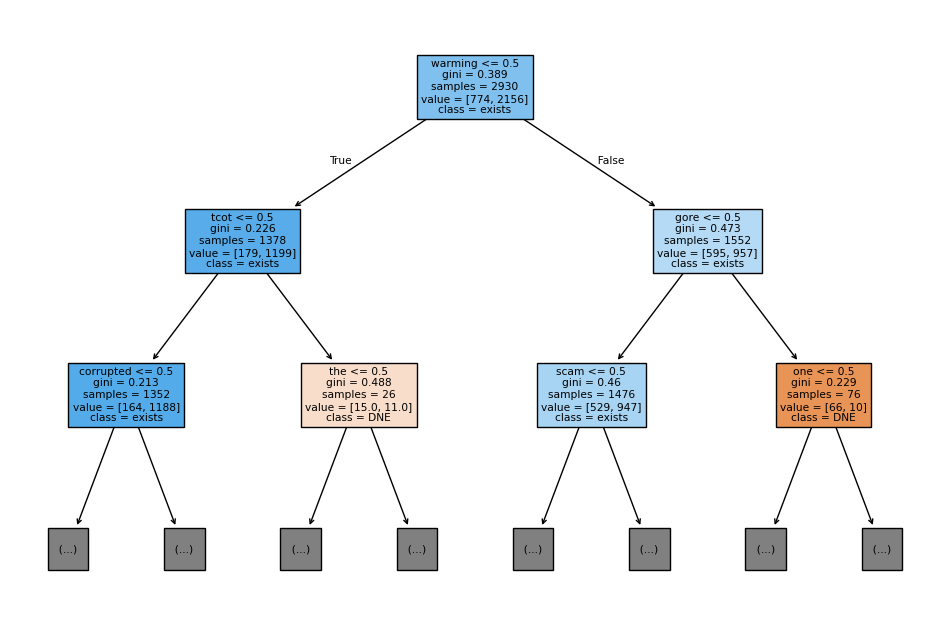

```python
plt.figure(figsize=(12,8))
plot_tree(clf, max_depth=2, filled=True, feature_names=X_train.columns.tolist(), class_names=class_names)
plt.show()
```

## 5.d. compute information gain

- compute I(Y,$x_i$) (for a split on the **training data**)
  - information gain I(Y,$x_i$) = H(Y) - H(Y|$x_i$)
  - entropy H(X) = $-\sum_{x \in X} p(x)log_2p(x)$
- report the outputs of this function for the **topmost split from 5.c.**
- as well as other keywords
- only consider whether the keyword exists

```python
def entropy(x):
    # x is a 1darray of targets
    # calc probs i.e. the proportion of each class
    # np.bincount always start from the smallest class i.e. 0 for class=[0,1]
    probs = np.bincount(x)/len(x)
    # np.bincount may include 0s if the bin has no count
    # should get rid of 0s by using p > 0
    return -np.sum([p * np.log2(p) for p in probs if p > 0])
```

```python
def compute_information_gain(X_train,y_train,xi):
    '''
    X_trian is a df that we are about to split at the root node
    y_train is Y, which is an array of targets of that df (X_train)
    xi is the keyword that we are using for splitting
    '''
    # root entropy = H(Y)
    root_entropy = entropy(y_train)

    # leafs entropy = H(Y|x_i)
    # = H(Y|x_i = True) * P(x_i = True) + H(Y|x_i = False) * P(x_i = False)
    mask_xi_true = X_train[xi] > 0
    mask_xi_false = X_train[xi]==0
    y_true = y_train[mask_xi_true]
    y_false = y_train[mask_xi_false]
    y_true_prob = len(y_true)/len(y_train)
    y_false_prob = 1-y_true_prob

    leafs_entropy = entropy(y_true) * y_true_prob + entropy(y_false) * y_false_prob

    information_gain = root_entropy - leafs_entropy
    return root_entropy, leafs_entropy, information_gain
```

```python
# for the topmost split from the previous part
root_entropy, leafs_entropy, information_gain = compute_information_gain(X_train,y_train,'warming')
print(f"from the plot in 5.c. the top split has information gain = {round(information_gain, 3)}.")
```

```
from the plot in 5.c. the top split has information gain = 0.062.
```

```python
# to double check
clf_check,accuracy_check = select_tree_model(X_train, y_train, X_val, y_val, 1, 'information_gain')
tree_check = clf_check.tree_
root_entropy_check = tree_check.impurity[0]
left_leaf_entropy_check = tree_check.impurity[1]
right_leaf_entropy_check = tree_check.impurity[2]
left_leaf_proportion_check = tree_check.n_node_samples[1] / tree_check.n_node_samples[0]
right_leaf_proportion_check = tree_check.n_node_samples[2] / tree_check.n_node_samples[0]
leafs_entropy_check = left_leaf_entropy_check * left_leaf_proportion_check + right_leaf_entropy_check * right_leaf_proportion_check
information_gain_check = root_entropy_check - leafs_entropy_check

function_above_vals = {
      'root_entropy': root_entropy,
      'leafs_entropy': leafs_entropy,
      'information_gain': information_gain
}

check_from_tree_vals = {
      'root_entropy': root_entropy_check,
      'leafs_entropy': leafs_entropy_check,
      'information_gain': information_gain_check
}

df_check = pd.DataFrame(
      [function_above_vals, check_from_tree_vals],
      index=['function_above', 'check_from_tree']
)

print(df_check)
# plt.figure(figsize=(6,4))
# plot_tree(clf_check, max_depth=2, filled=True, feature_names=X_train.columns.tolist(), class_names=class_names)
# plt.show()
```

```
                 root_entropy  leafs_entropy  information_gain
function_above       0.832965       0.770749          0.062216
check_from_tree      0.832965       0.770749          0.062216
```

```python
# for other several keywords

keywords = ['president','scientists','conspiracy','school','hot']
for k in keywords:
    root_entropy, leafs_entropy, information_gain = compute_information_gain(X_train,y_train,k)
    print(f'keyword: {k}, information gain: {information_gain}')
```

```
keyword: president, information gain: 0.0009648045919823378
keyword: scientists, information gain: 2.872997182856718e-05
keyword: conspiracy, information gain: 0.006578124860050605
keyword: school, information gain: 0.00010732191986118078
keyword: hot, information gain: 0.0014530708874183063
```

## 5.e.

write a function **select_knn_model**:

- use a range of k between 1~20
- compute training and val errors
- generate a graph for k vs. training error
- report the generated graph in your report
- choose the model with the best validation accuracy and report its accuracy on the test data

```python
def select_knn_model(X_train,y_train,X_test,y_test,k):
    # for some reasons it raises the following error when using original dataframes and series
    # AttributeError: 'Flags' object has no attribute 'c_contiguous'

    # change to np.array instead
    X_train = np.array(X_train)
    y_train = np.array(y_train)
    X_test = np.array(X_test)
    y_test = np.array(y_test)

    knn = KNeighborsClassifier(n_neighbors=k)
    knn.fit(X_train, y_train)

    pred_training = knn.predict(X_train)
    training_accuracy = accuracy_score(y_train, pred_training)
    training_error = 1 - training_accuracy
    pred_testing = knn.predict(X_test)
    test_accuracy = accuracy_score(y_test, pred_testing)
    test_error = 1 - test_accuracy

    return training_error, test_error
```

```python
# training and validation errors in k range of 1~20
ks = np.arange(1,21,1)
training_errors = []
val_errors = []
for k in ks:
    training_error, val_error = select_knn_model(X_train,y_train,X_val,y_val,k)
    training_errors.append(training_error)
    val_errors.append(val_error)
```

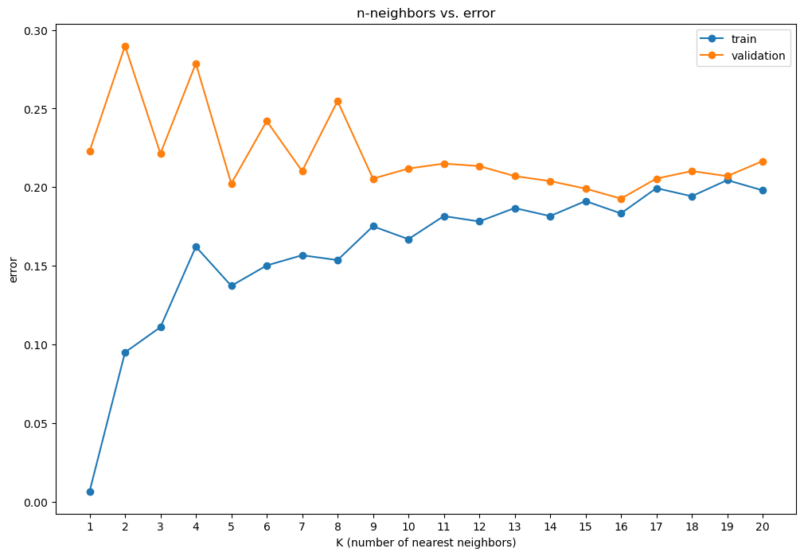

```python
plt.figure(figsize=(12,8))
plt.plot(ks, training_errors, marker='o', label='train')
plt.plot(ks, val_errors, marker='o', label='validation')
plt.xticks(ks)
plt.xlabel('K (number of nearest neighbors)')
plt.ylabel('error')
plt.title('n-neighbors vs. error')
plt.legend()
plt.show()
```

```python
# find the k that has the best validation accuracy (lowest error)
# need to +1 to the index
best_k = np.argmin(val_errors)+1
print(f'best k is {best_k}')
training_error, test_error = select_knn_model(X_train,y_train,X_test,y_test,best_k)
# accuracy = 1 - error
print(f'accuracy on the test set with the best k={best_k} is {round(1-test_error, 3)}')
```

```
best k is 16
accuracy on the test set with the best k=16 is 0.776
```